# Splines and Cross Validation

STAT 380

# Loading the BostonHousing Data

1. Using the read.csv() command: Read in the R worksopace as the name ‘Daten’ Note that the names are case sensitive. that is ‘Daten’ is not same as ‘daten’.
2. Apply the basic functions on the data.frame ‘Daten’ to check its structure.

```r
#########################################################################
# STAT380: Statistical Machine Learning
# Content: Dataset Boston housing
#########################################################################

#Daten<-read.csv("")

Daten<-read.csv("https://raw.githubusercontent.com/subhadippal2019/STAT380UAEU/main/BostonHousing.csv")
#Daten


# Additional information for a quick check to identify whether the data is loaded appropriately
head(Daten, 6) # shows the first 6 rows from the data.
```

```
##      CRIM ZN INDUS CHAS   NOX    RM  AGE    DIS RAD TAX PTRATIO LSTAT MEDV
## 1 0.00632 18  2.31    0 0.538 6.575 65.2 4.0900   1 296    15.3  4.98 24.0
## 2 0.02731  0  7.07    0 0.469 6.421 78.9 4.9671   2 242    17.8  9.14 21.6
## 3 0.02729  0  7.07    0 0.469 7.185 61.1 4.9671   2 242    17.8  4.03 34.7
## 4 0.03237  0  2.18    0 0.458 6.998 45.8 6.0622   3 222    18.7  2.94 33.4
## 5 0.06905  0  2.18    0 0.458 7.147 54.2 6.0622   3 222    18.7  5.33 36.2
## 6 0.02985  0  2.18    0 0.458 6.430 58.7 6.0622   3 222    18.7  5.21 28.7
##   CAT..MEDV
## 1         0
## 2         0
## 3         1
## 4         1
## 5         1
## 6         0
```

```r
str(Daten) # provides structure of an R object in general. In this case it will show the names of the variables inside it.
```

```
## 'data.frame':    506 obs. of  14 variables:
##  $ CRIM     : num  0.00632 0.02731 0.02729 0.03237 0.06905 ...
##  $ ZN       : num  18 0 0 0 0 0 12.5 12.5 12.5 12.5 ...
##  $ INDUS    : num  2.31 7.07 7.07 2.18 2.18 2.18 7.87 7.87 7.87 7.87 ...
##  $ CHAS     : int  0 0 0 0 0 0 0 0 0 0 ...
##  $ NOX      : num  0.538 0.469 0.469 0.458 0.458 0.458 0.524 0.524 0.524 0.524 ...
##  $ RM       : num  6.58 6.42 7.18 7 7.15 ...
##  $ AGE      : num  65.2 78.9 61.1 45.8 54.2 58.7 66.6 96.1 100 85.9 ...
##  $ DIS      : num  4.09 4.97 4.97 6.06 6.06 ...
##  $ RAD      : int  1 2 2 3 3 3 5 5 5 5 ...
##  $ TAX      : int  296 242 242 222 222 222 311 311 311 311 ...
##  $ PTRATIO  : num  15.3 17.8 17.8 18.7 18.7 18.7 15.2 15.2 15.2 15.2 ...
##  $ LSTAT    : num  4.98 9.14 4.03 2.94 5.33 ...
##  $ MEDV     : num  24 21.6 34.7 33.4 36.2 28.7 22.9 27.1 16.5 18.9 ...
##  $ CAT..MEDV: int  0 0 1 1 1 0 0 0 0 0 ...
```

```r
summary(Daten) # This commands provides the summary of all the variables of the dataset.
```

```
##       CRIM                ZN             INDUS            CHAS
##  Min.   : 0.00632   Min.   :  0.00   Min.   : 0.46   Min.   :0.00000
##  1st Qu.: 0.08205   1st Qu.:  0.00   1st Qu.: 5.19   1st Qu.:0.00000
##  Median : 0.25651   Median :  0.00   Median : 9.69   Median :0.00000
##  Mean   : 3.61352   Mean   : 11.36   Mean   :11.14   Mean   :0.06917
##  3rd Qu.: 3.67708   3rd Qu.: 12.50   3rd Qu.:18.10   3rd Qu.:0.00000
##  Max.   :88.97620   Max.   :100.00   Max.   :27.74   Max.   :1.00000
##       NOX               RM             AGE              DIS
##  Min.   :0.3850   Min.   :3.561   Min.   :  2.90   Min.   : 1.130
##  1st Qu.:0.4490   1st Qu.:5.886   1st Qu.: 45.02   1st Qu.: 2.100
##  Median :0.5380   Median :6.208   Median : 77.50   Median : 3.207
##  Mean   :0.5547   Mean   :6.285   Mean   : 68.57   Mean   : 3.795
##  3rd Qu.:0.6240   3rd Qu.:6.623   3rd Qu.: 94.08   3rd Qu.: 5.188
##  Max.   :0.8710   Max.   :8.780   Max.   :100.00   Max.   :12.127
##       RAD              TAX           PTRATIO          LSTAT
##  Min.   : 1.000   Min.   :187.0   Min.   :12.60   Min.   : 1.73
##  1st Qu.: 4.000   1st Qu.:279.0   1st Qu.:17.40   1st Qu.: 6.95
##  Median : 5.000   Median :330.0   Median :19.05   Median :11.36
##  Mean   : 9.549   Mean   :408.2   Mean   :18.46   Mean   :12.65
##  3rd Qu.:24.000   3rd Qu.:666.0   3rd Qu.:20.20   3rd Qu.:16.95
##  Max.   :24.000   Max.   :711.0   Max.   :22.00   Max.   :37.97
##       MEDV         CAT..MEDV
##  Min.   : 5.00   Min.   :0.000
##  1st Qu.:17.02   1st Qu.:0.000
##  Median :21.20   Median :0.000
##  Mean   :22.53   Mean   :0.166
##  3rd Qu.:25.00   3rd Qu.:0.000
##  Max.   :50.00   Max.   :1.000
```

# Data Partition

1. Split data in two partitions (80% Training, 20% Validation)
2. set.seed(10)
3. Use the function create Data Partition from `caret’ package.
4. Read the help manual for the function `createDataPartition’ The corresponding command is ‘?createDataPartition’ OR ‘help(createDataPartition)’

```r
#########################################################################
  # 2. Data Partitioning
  #########################################################################

 # Split data in three partitions (80% Training, 20% Validation)

  library(caret)
#install.packages('caret') # Use this command to install the package,  if case the package is not installed and you get an error "rror in library(caret) : there is no package called ‘caret’"
  set.seed(10) # An optional argument butr sometimes convinient to set the see to reproduce the result.
  #We are going to use the createDataPartition function. Hence see the documentation on the function
 # help(createDataPartition)
```

```r
library(caret)

createDataPartition_alt<-function(y,p = 0.5, list=FALSE){
  n=length(y)
  Train_size=round(n*p)
  sel_sample=sample(x = 1:n,size =Train_size ,replace = FALSE)
  return(sel_sample)
}
```

```r
  Daten=na.omit(Daten)
  #inTrain = createDataPartition(Daten$CRIM, p = 0.8, list = FALSE)
  inTrain = createDataPartition_alt(Daten$CRIM, p = 0.8, list = FALSE)
  train = Daten[inTrain, ]
  dim(train)
```

```
## [1] 405  14
```

```r
  dim(Daten)
```

```
## [1] 506  14
```

## Creating the Testing Set

1. Create the Testing set ‘test’. Not ethat test set will have all the data rows that are not included in the trainig set.
2. Plot the variable ‘MEDV’ available in the ‘train’ and ‘test’ dataset and plot the points in a different color
3. Put the legend command to see what changes does it make to the plot.

```r
  test = Daten[-inTrain,]
  dim(test)
```

```
## [1] 101  14
```

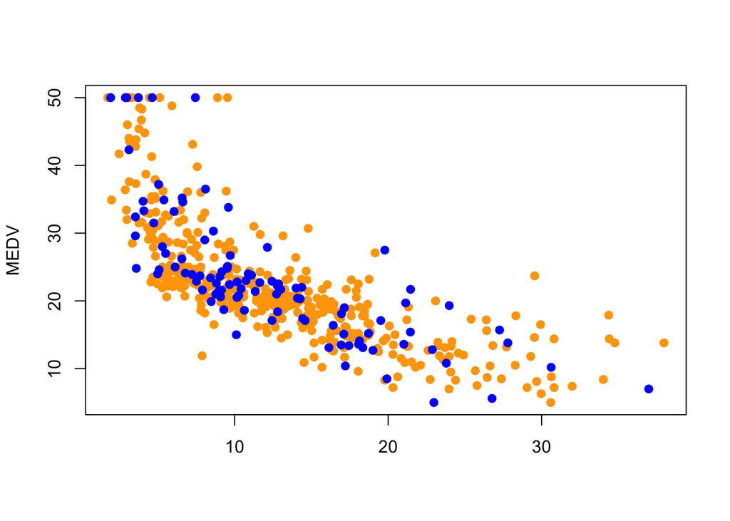

```r
  plot(train$LSTAT, train$MEDV, col="orange", pch=19 , ylab="MEDV", xlab="")
  points(test$LSTAT, test$MEDV,col="blue", pch=19)
  legend(280, 47, legend=c("train$MEDV",  "test$MEDV"),
         col=c("orange" ,"blue"), lty=1:2, cex=0.8)
```

# Fitting a Polynomial

1. We fit in the training dataset and check its performance from the testing dataset Degree of the polynomial is 2 in the following example. I.e. the function of the type $\beta_0+\beta_1 X+\beta_2X^2$ will be considered.

```r
model_polynomial <- lm(MEDV ~ poly(LSTAT, 2, raw = TRUE), data= train)


#model_linear = lm(MEDV ~ LSTAT, data = train);
summary(model_polynomial)
```

```
##
## Call:
## lm(formula = MEDV ~ poly(LSTAT, 2, raw = TRUE), data = train)
##
## Residuals:
##      Min       1Q   Median       3Q      Max
## -15.0806  -3.8866  -0.3915   2.3088  25.5758
##
## Coefficients:
##                              Estimate Std. Error t value Pr(>|t|)
## (Intercept)                 42.432448   0.965929   43.93   <2e-16 ***
## poly(LSTAT, 2, raw = TRUE)1 -2.301207   0.136649  -16.84   <2e-16 ***
## poly(LSTAT, 2, raw = TRUE)2  0.043186   0.004116   10.49   <2e-16 ***
## ---
## Signif. codes:  0 '***' 0.001 '**' 0.01 '*' 0.05 '.' 0.1 ' ' 1
##
## Residual standard error: 5.445 on 402 degrees of freedom
## Multiple R-squared:  0.6392, Adjusted R-squared:  0.6374
## F-statistic: 356.1 on 2 and 402 DF,  p-value: < 2.2e-16
```

```r
#Make predictions
library(forecast)
predictions_test =  predict(object =model_polynomial,newdata= test )

  #MOdel performance on the Testing Data
 data.frame(RMSE = RMSE(predictions_test, test$MEDV), R2 = R2(predictions_test, test$MEDV))
```

```
##       RMSE        R2
## 1 5.839985 0.6488598
```

```r
  accuracy(predictions_test, test$MEDV)
```

```
##                 ME     RMSE      MAE       MPE     MAPE
## Test set 0.5292977 5.839985 4.275274 -4.846819 20.31902
```

```r
  #MOdel performance on the Training Data
 predictions_train =  predict(object =model_polynomial,newdata= train )
 data.frame(RMSE = RMSE(predictions_train, train$MEDV), R2 = R2(predictions_train, train$MEDV))
```

```
##       RMSE        R2
## 1 5.424907 0.6392125
```

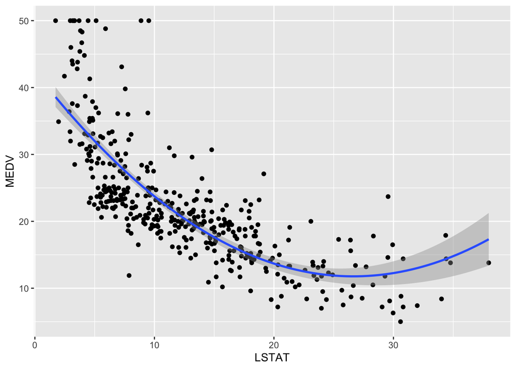

```r
plt<-ggplot(train, aes(LSTAT, MEDV) ) + geom_point() +stat_smooth(method = lm, formula = y ~ poly(x, 2, raw =TRUE))
plt
```

## Checking the model Assumptions:

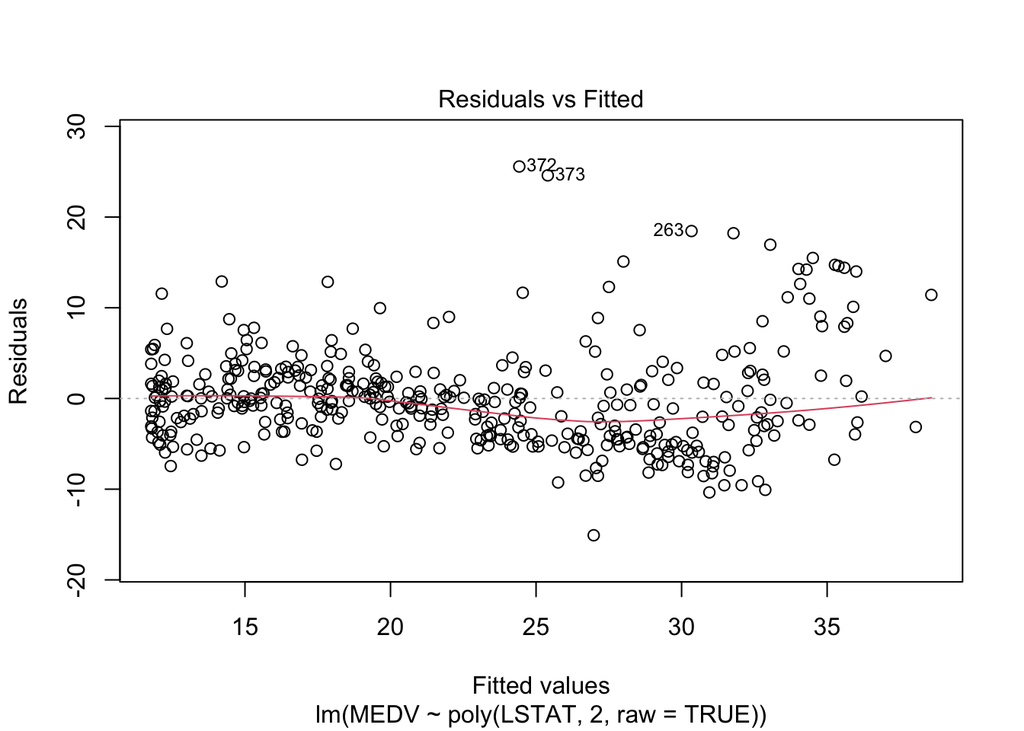

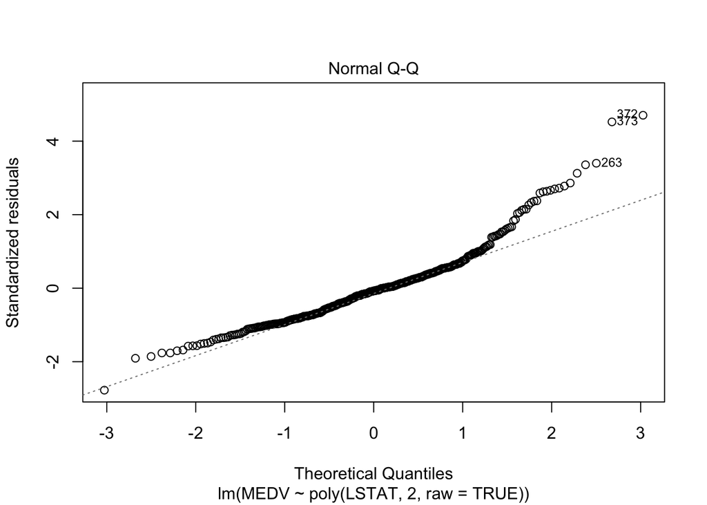

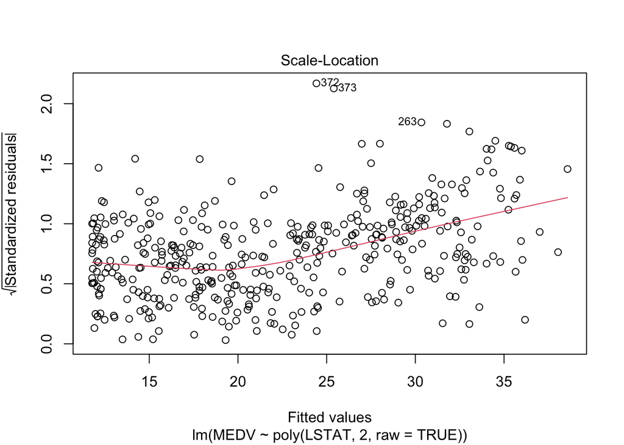

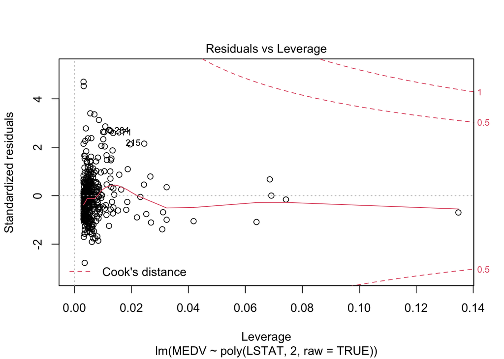

```r
plot(model_polynomial)
```

# Fitting a Regression Splines

## 1) Consider Fiting a piecewise Line

Step1: Identify the regions to put the knots Step2: Fit a spline Step3: plot the results

```r
#install.packages("splines")
library(splines)
 # Build the model
knots <- quantile(train$LSTAT, p = c(0.25, .5,  0.75))
model_ss1 <- lm (MEDV ~ bs(LSTAT, knots = knots, degree=1),  data =train)
summary(model_ss1)
```

```
##
## Call:
## lm(formula = MEDV ~ bs(LSTAT, knots = knots, degree = 1), data = train)
##
## Residuals:
##      Min       1Q   Median       3Q      Max
## -12.2749  -3.1638  -0.8243   2.4137  26.9017
##
## Coefficients:
##                                       Estimate Std. Error t value Pr(>|t|)
## (Intercept)                             46.159      1.290   35.77   <2e-16 ***
## bs(LSTAT, knots = knots, degree = 1)1  -21.358      1.686  -12.67   <2e-16 ***
## bs(LSTAT, knots = knots, degree = 1)2  -24.451      1.385  -17.65   <2e-16 ***
## bs(LSTAT, knots = knots, degree = 1)3  -29.901      1.449  -20.64   <2e-16 ***
## bs(LSTAT, knots = knots, degree = 1)4  -37.660      1.996  -18.87   <2e-16 ***
## ---
## Signif. codes:  0 '***' 0.001 '**' 0.01 '*' 0.05 '.' 0.1 ' ' 1
##
## Residual standard error: 5.158 on 400 degrees of freedom
## Multiple R-squared:  0.6779, Adjusted R-squared:  0.6747
## F-statistic: 210.5 on 4 and 400 DF,  p-value: < 2.2e-16
```

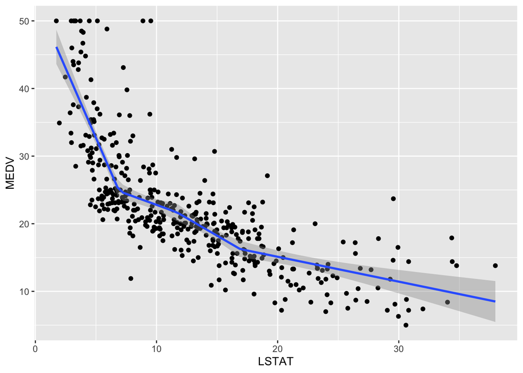

```r
ggplot(train, aes(LSTAT, MEDV) ) + geom_point() +
stat_smooth(method = lm, formula = y ~ splines::bs(x, knots = knots, degree=1))
```

## 1) Consider Fiting a piecewise polynomial of degree 2

```r
#install.packages("splines")
 # Build the model
knots <- quantile(train$LSTAT, p = c(0.25, .5,  0.9))
model_ss2 <- lm (MEDV ~ bs(LSTAT, knots = knots, degree=2),  data =train)
summary(model_ss2)
```

```
##
## Call:
## lm(formula = MEDV ~ bs(LSTAT, knots = knots, degree = 2), data = train)
##
## Residuals:
##      Min       1Q   Median       3Q      Max
## -14.9561  -3.1347  -0.7419   2.0374  26.7507
##
## Coefficients:
##                                       Estimate Std. Error t value Pr(>|t|)
## (Intercept)                             51.980      2.123  24.488  < 2e-16 ***
## bs(LSTAT, knots = knots, degree = 2)1  -22.514      2.928  -7.688 1.17e-13 ***
## bs(LSTAT, knots = knots, degree = 2)2  -28.709      2.066 -13.898  < 2e-16 ***
## bs(LSTAT, knots = knots, degree = 2)3  -35.761      2.429 -14.722  < 2e-16 ***
## bs(LSTAT, knots = knots, degree = 2)4  -43.532      2.681 -16.236  < 2e-16 ***
## bs(LSTAT, knots = knots, degree = 2)5  -36.677      4.060  -9.034  < 2e-16 ***
## ---
## Signif. codes:  0 '***' 0.001 '**' 0.01 '*' 0.05 '.' 0.1 ' ' 1
##
## Residual standard error: 5.109 on 399 degrees of freedom
## Multiple R-squared:  0.6848, Adjusted R-squared:  0.6808
## F-statistic: 173.4 on 5 and 399 DF,  p-value: < 2.2e-16
```

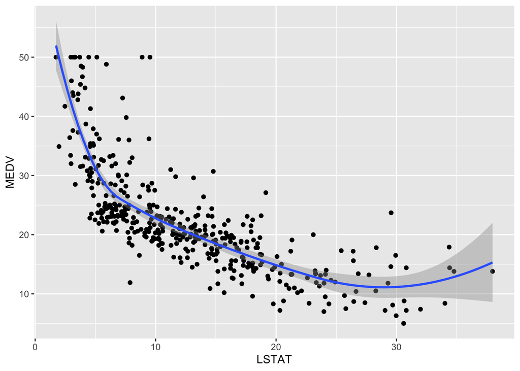

```r
ggplot(train, aes(LSTAT, MEDV) ) + geom_point() +
stat_smooth(method = lm, formula = y ~ splines::bs(x, knots = knots, degree=2))
```

## 1) Consider Fiting a piecewise polynomial of degree 3 ( most popular choice also the default option)

```r
#install.packages("splines")
library(splines)
 # Build the model
knots <- quantile(train$LSTAT, p = c(0.25, .5,  0.75))
model_ss3 <- lm (MEDV ~ bs(LSTAT, knots = knots),  data =train)
summary(model_ss3)
```

```
##
## Call:
## lm(formula = MEDV ~ bs(LSTAT, knots = knots), data = train)
##
## Residuals:
##      Min       1Q   Median       3Q      Max
## -12.7884  -3.0077  -0.7195   2.0113  27.3480
##
## Coefficients:
##                           Estimate Std. Error t value Pr(>|t|)
## (Intercept)                 49.324      2.958  16.677  < 2e-16 ***
## bs(LSTAT, knots = knots)1  -11.488      4.369  -2.629  0.00889 **
## bs(LSTAT, knots = knots)2  -26.715      2.786  -9.589  < 2e-16 ***
## bs(LSTAT, knots = knots)3  -26.955      3.316  -8.128 5.58e-15 ***
## bs(LSTAT, knots = knots)4  -38.776      3.446 -11.251  < 2e-16 ***
## bs(LSTAT, knots = knots)5  -39.600      4.743  -8.349 1.15e-15 ***
## bs(LSTAT, knots = knots)6  -34.760      4.759  -7.305 1.53e-12 ***
## ---
## Signif. codes:  0 '***' 0.001 '**' 0.01 '*' 0.05 '.' 0.1 ' ' 1
##
## Residual standard error: 5.125 on 398 degrees of freedom
## Multiple R-squared:  0.6836, Adjusted R-squared:  0.6788
## F-statistic: 143.3 on 6 and 398 DF,  p-value: < 2.2e-16
```

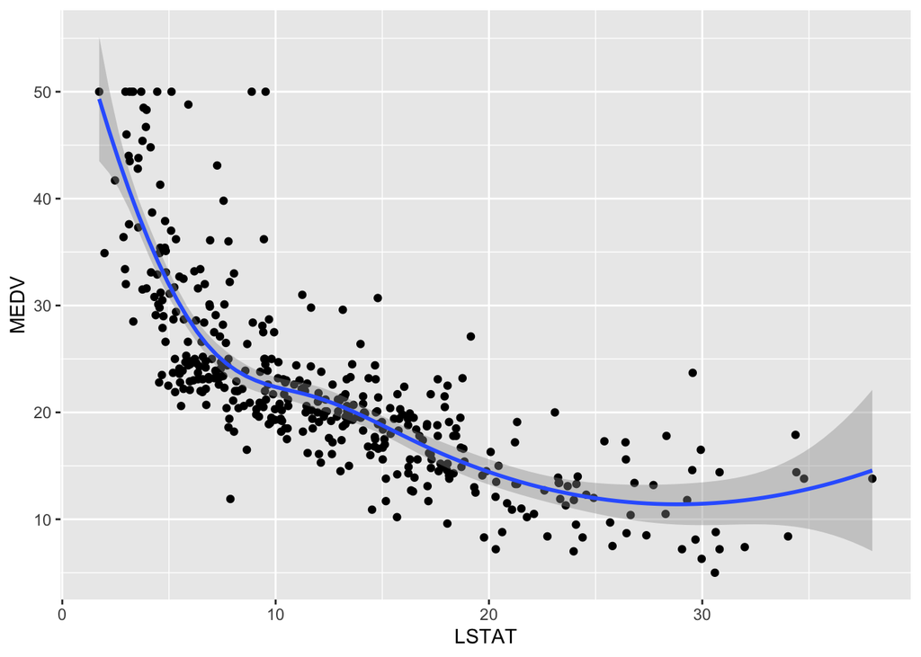

```r
ggplot(train, aes(LSTAT, MEDV) ) + geom_point() +
stat_smooth(method = lm, formula = y ~ splines::bs(x, knots = knots))
```

## Prediction Based on the 3 degree polynomial Fit.

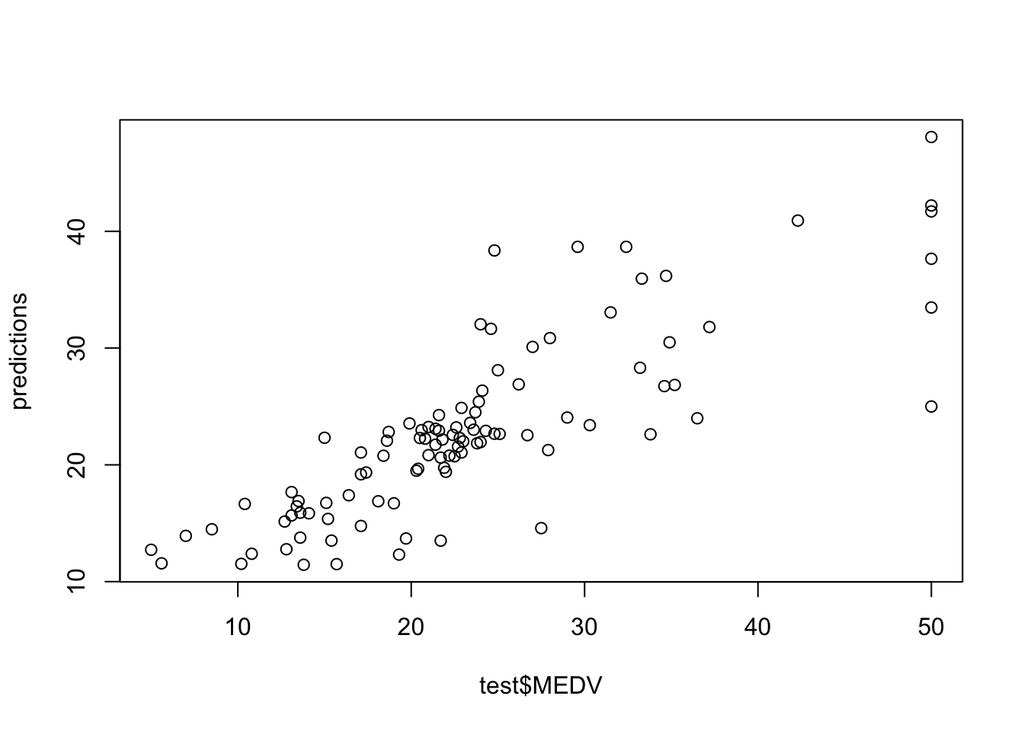

```r
#predictions <- modelss %>% predict(test)
predictions <-  predict(model_ss3, test)
plot(test$MEDV , predictions)
```

```r
# Model performance
data.frame(
RMSE = RMSE(predictions, test$MEDV),
R2 = R2(predictions, test$MEDV))
```

```
##       RMSE        R2
## 1 5.559719 0.6789511
```

# Cross Validation

```r
set.seed(11)
fit<-glm(MEDV~CRIM+RM+PTRATIO,data=Daten)

library(boot)
# Leave-one-out cross-validation
cv_one_err<-cv.glm(Daten,fit)
cv_one_err$delta
```

```
## [1] 35.00064 34.99989
```

```r
# 5 fold Cross Validation
cv_5_err<-cv.glm(Daten,fit,K=5)
cv_5_err$delta
```

```
## [1] 36.09778 35.89034
```

```r
cv_error<-NULL

 for(i in 1:6){
    fit_poly<-glm(MEDV~poly(CRIM,degree=i)+RM+PTRATIO,data=Daten)
    cv_error[i]<-cv.glm(Daten,fit_poly,K=5)$delta[1]
 }
 cv_error
```

```
## [1]    36.50394    34.61901    35.16963    34.97346    69.66155 13168.04656
```

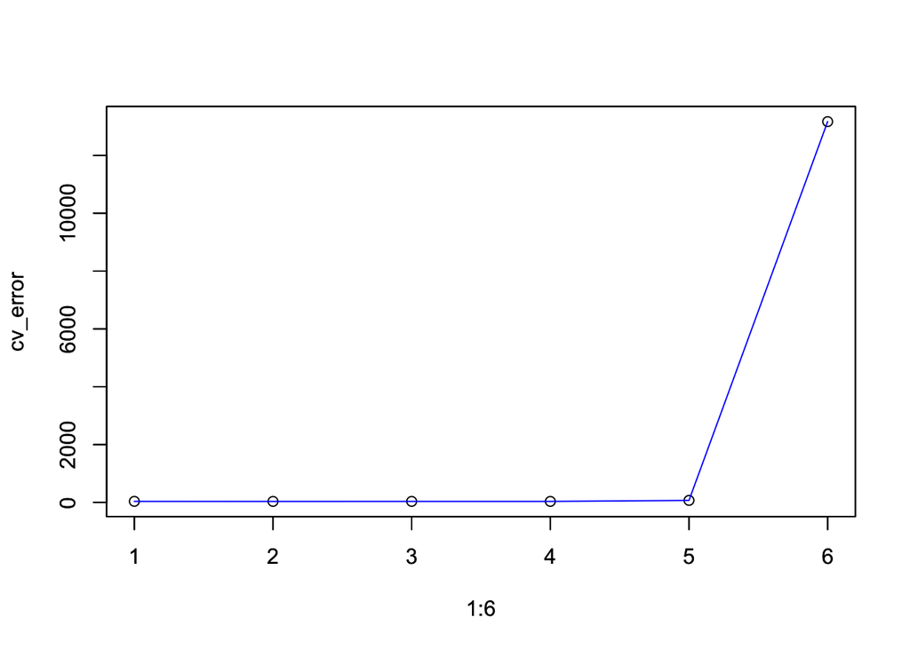

```r
#[1] 34.708 34.813 35.076 34.423 41.874 51.530

plot(1:6, cv_error)
par(new=TRUE)
plot(1:6, cv_error, type="l", col="blue")
```

## Preparation for the next class

```r
#install.packages("glmnet"
library(glmnet)
```